# Code - From little things, big things grow: using applied nucleation to restore marine forests

```r
AICc(my_lmerOX)
```

```
## [1] 92.39248
```

```r
check_model(my_lmerOX)
```

```
## `check_outliers()` does not yet support models of class `glmmTMB`.
```

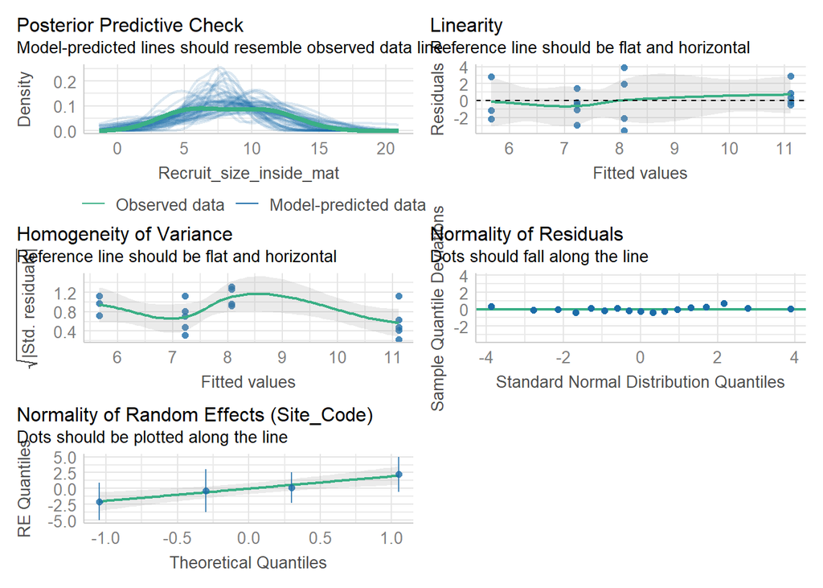

Plot relationship

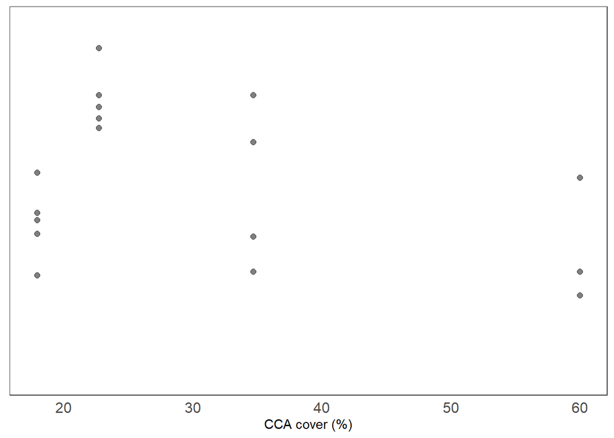

```r
EC_Recl9 <- ggplot() +
   geom_point(data = Rec_l9,                      # adding the raw data (scaled values)
              aes(x = Encrusting_macroalgae, y = Recruit_size_inside_mat), size= 2, alpha=.5) +
   labs(x = "CCA cover (%)", y = expression(sqrt("Recruit length"))) +
   Theme1 +
  scale_y_continuous(limits = c(0, 15), breaks = seq(0,15, by = 3))+
  theme(axis.title.y=element_blank(),
        axis.text.y=element_blank(), axis.title.x=element_text(size = 11))

EC_Recl9
```

6. Survival

```r
my_lmerHF <- glmmTMB(Recruit_size_inside_mat ~ Survival_Percentage + (1|Site_Code), data=Rec_l9, gaussian())
summary(my_lmerHF)
```

```
##  Family: gaussian  ( identity )
## Formula:
## Recruit_size_inside_mat ~ Survival_Percentage + (1 | Site_Code)
## Data: Rec_l9
##
##      AIC      BIC   logLik deviance df.resid
##     89.5     92.8    -40.7     81.5       13
##
## Random effects:
##
## Conditional model:
##  Groups    Name        Variance Std.Dev.
##  Site_Code (Intercept) 3.473    1.864
##  Residual              5.145    2.268
## Number of obs: 17, groups:  Site_Code, 4
##
## Dispersion estimate for gaussian family (sigma^2): 5.15
##
## Conditional model:
##                     Estimate Std. Error z value Pr(>|z|)
## (Intercept)           5.2176     3.1562   1.653   0.0983 .
## Survival_Percentage   0.1006     0.1038   0.969   0.3325
## ---
## Signif. codes:  0 '***' 0.001 '**' 0.01 '*' 0.05 '.' 0.1 ' ' 1
```

```r
r.squaredGLMM(my_lmerHF)
```

```
##           R2m       R2c
## [1,] 0.120876 0.4751449
```

```r
AICc(my_lmerHF)
```

```
## [1] 92.79157
```

```r
check_model(my_lmerHF)
```

```
## `check_outliers()` does not yet support models of class `glmmTMB`.
```

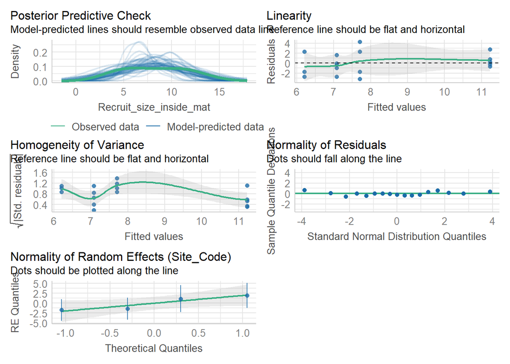

Plot relationship

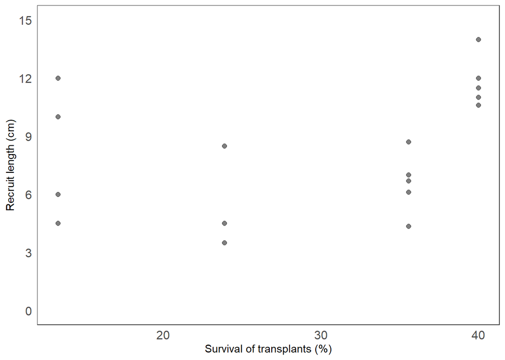

```r
Surv_Recl9 <- ggplot() +
   geom_point(data = Rec_l9,                      # adding the raw data (scaled values)
              aes(x = Survival_Percentage, y = Recruit_size_inside_mat), size= 2, alpha=.5) +
   labs(x = "Survival of transplants (%)", y = "Recruit length (cm)") +
   Theme1 +
  scale_y_continuous(limits = c(0, 15), breaks = seq(0,15, by = 3))+
  theme(axis.title.x=element_text(size = 11), axis.title.y=element_text(size = 11))

Surv_Recl9
```

7. Grazing

```r
glmm_gr <- glmmTMB(Recruit_size_inside_mat ~ Mean_Grazing + (1|Site_Code), data=Rec_l9, gaussian())
summary(glmm_gr)
```

```
##  Family: gaussian  ( identity )
## Formula:          Recruit_size_inside_mat ~ Mean_Grazing + (1 | Site_Code)
## Data: Rec_l9
##
##      AIC      BIC   logLik deviance df.resid
##     85.9     89.2    -39.0     77.9       13
##
## Random effects:
##
## Conditional model:
##  Groups    Name        Variance Std.Dev.
##  Site_Code (Intercept) 0.7514   0.8668
##  Residual              5.1136   2.2613
## Number of obs: 17, groups:  Site_Code, 4
##
## Dispersion estimate for gaussian family (sigma^2): 5.11
##
## Conditional model:
##              Estimate Std. Error z value Pr(>|z|)
## (Intercept)   13.3025     1.9406   6.855 7.14e-12 ***
## Mean_Grazing  -1.7494     0.6195  -2.824  0.00474 **
## ---
## Signif. codes:  0 '***' 0.001 '**' 0.01 '*' 0.05 '.' 0.1 ' ' 1
```

```r
r.squaredGLMM(glmm_gr)
```

```
##            R2m       R2c
## [1,] 0.4167455 0.4914662
```

```r
AICc(glmm_gr)
```

```
## [1] 89.24859
```

```r
check_model(glmm_gr)
```

```
## `check_outliers()` does not yet support models of class `glmmTMB`.
```

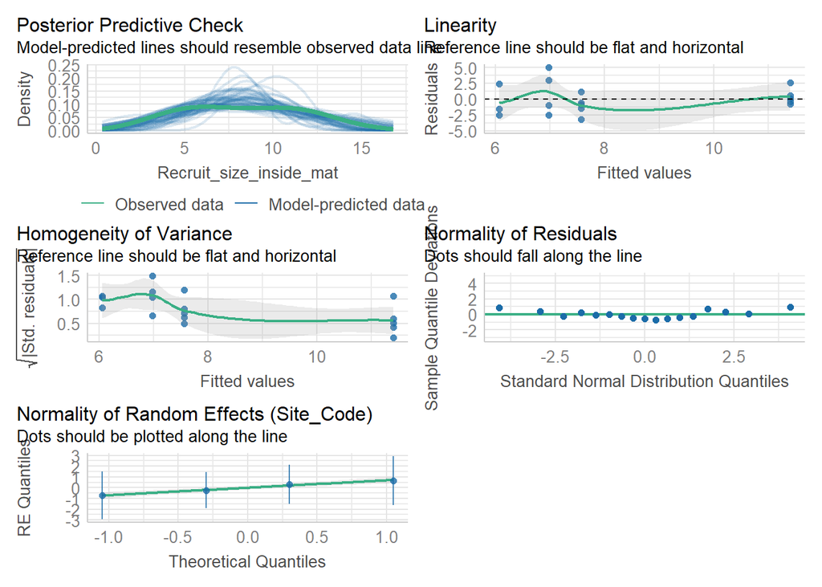

Calculate predicted values

```r
all_sites <- unique(Rec_l9$Site_Code)
new_data <-expand.grid(Mean_Grazing = seq(min(Rec_l9$Mean_Grazing), max(Rec_l9$Mean_Grazing), length.out = 100),
  Site_Code = all_sites)
predictions <- predict(glmm_gr, newdata = new_data, type = "link", se.fit = TRUE, re.form = ~0)
# Combine predicted values with new_data
ilink <- family(glmm_gr)$linkinv
pred <- cbind(new_data, predictions)
pred <- transform(pred, conf.low = ilink(fit - (2 * se.fit)),
                        conf.high = ilink(fit + (2 * se.fit)),
                        predicted = ilink(fit))
```

Plot relationships

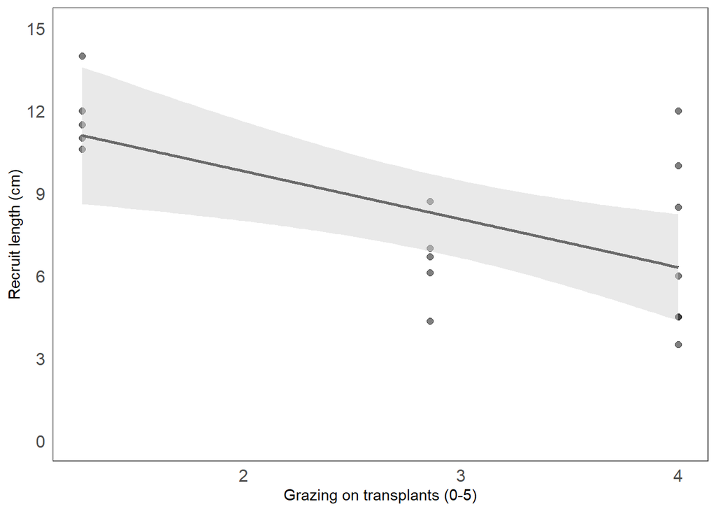

```r
Gr_Recl9 <- ggplot() +
   geom_point(data = Rec_l9,                      # adding the raw data (scaled values)
              aes(x = Mean_Grazing, y = Recruit_size_inside_mat), size= 2, alpha=.5) +
   labs(x = "Grazing on transplants (0-5)", y = "Recruit length (cm)") +
   Theme1 +
  scale_y_continuous(limits = c(0, 15), breaks = seq(0,15, by = 3)) +
  geom_line(data = pred,
            aes(x = Mean_Grazing, y = predicted),
            color = "black", size = 1)   +
  geom_ribbon(data = pred,
              aes(x = Mean_Grazing, ymin = conf.low, ymax = conf.high),
              fill = "lightgrey", alpha = 0.5) +
  theme(axis.title.x=element_text(size = 11), axis.title.y=element_text(size = 11))

Gr_Recl9
```

```r
ggsave("Rl9_greaxing.jpeg", width = 90, height = 70, units = "mm")
Gr_Recl9 <- Gr_Recl9+
  theme(axis.title.y=element_blank(),
        axis.text.y=element_blank(), axis.title.x = element_text(size = 11))
```

8. Fouling

```r
glmm_f <- glmmTMB(Recruit_size_inside_mat ~ Percentage_fouling + (1|Site_Code), data=Rec_l9, gaussian())
summary(glmm_f)
```

```
##  Family: gaussian  ( identity )
## Formula:
## Recruit_size_inside_mat ~ Percentage_fouling + (1 | Site_Code)
## Data: Rec_l9
##
##      AIC      BIC   logLik deviance df.resid
##     81.0     84.4    -36.5     73.0       13
##
## Random effects:
##
## Conditional model:
##  Groups    Name        Variance  Std.Dev.
##  Site_Code (Intercept) 2.924e-09 5.408e-05
##  Residual              4.296e+00 2.073e+00
## Number of obs: 17, groups:  Site_Code, 4
##
## Dispersion estimate for gaussian family (sigma^2):  4.3
##
## Conditional model:
##                    Estimate Std. Error z value Pr(>|z|)
## (Intercept)        12.44900    1.01853  12.223  < 2e-16 ***
## Percentage_fouling -0.14463    0.03082  -4.693 2.69e-06 ***
## ---
## Signif. codes:  0 '***' 0.001 '**' 0.01 '*' 0.05 '.' 0.1 ' ' 1
```

```r
r.squaredGLMM(glmm_f)
```

```
##            R2m       R2c
## [1,] 0.5792141 0.5792141
```

```r
AICc(glmm_f)
```

```
## [1] 84.35686
```

```r
check_model(glmm_f)
```

```
## `check_outliers()` does not yet support models of class `glmmTMB`.
```

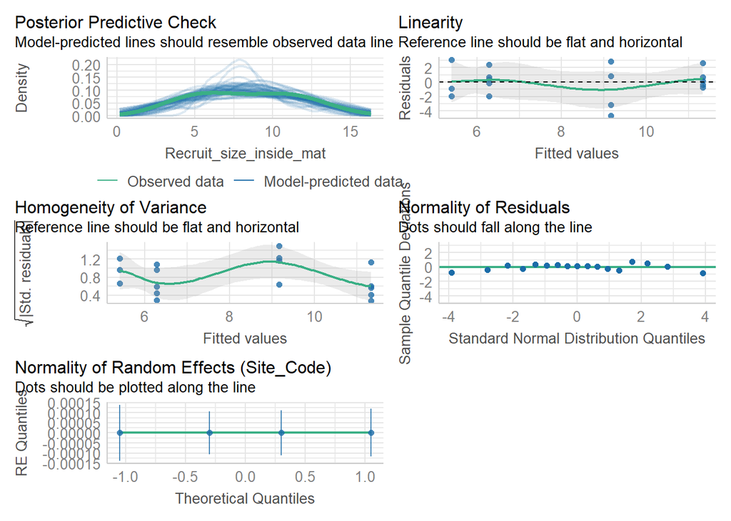

Plot relationship

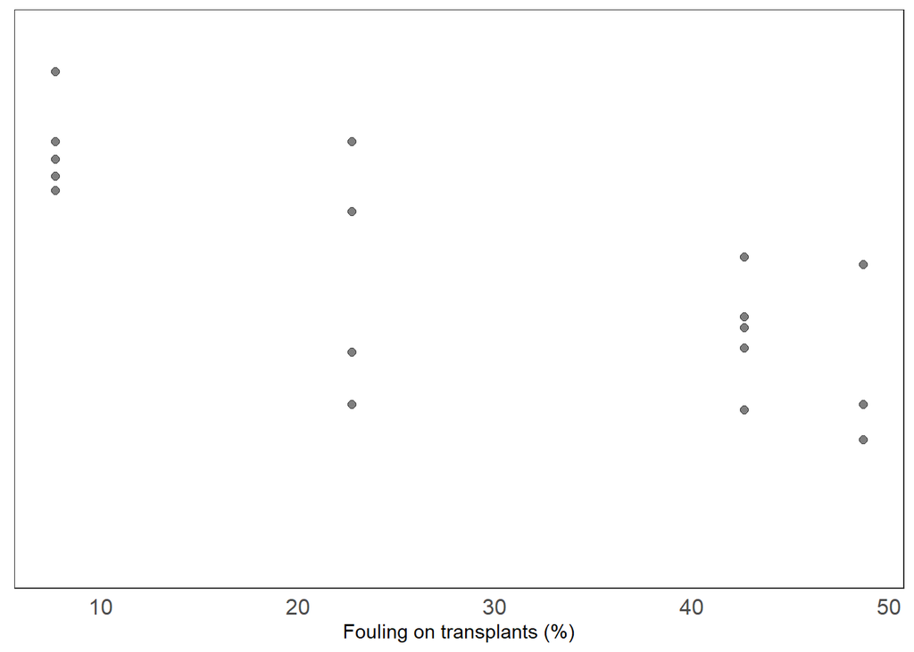

```r
Fo_Recl9 <- ggplot() +
   geom_point(data = Rec_l9,                      # adding the raw data (scaled values)
              aes(x = Percentage_fouling, y = Recruit_size_inside_mat), size= 2, alpha=.5) +
   labs(x = "Fouling on transplants (%)", y = "Recruit length (cm)") +
   Theme1 +
  scale_y_continuous(limits = c(0, 15), breaks = seq(0,15, by = 3)) +
  theme(axis.title.y=element_blank(),
        axis.text.y=element_blank(), axis.title.x=element_text(size = 11))

Fo_Recl9
```

9. Daily SD

```r
my_lmerOX <- glmmTMB(Recruit_size_inside_mat ~ Mean_SD + (1|Site_Code), data=Rec_l9, family = gaussian())
summary(my_lmerOX)
```

```
##  Family: gaussian  ( identity )
## Formula:          Recruit_size_inside_mat ~ Mean_SD + (1 | Site_Code)
## Data: Rec_l9
##
##      AIC      BIC   logLik deviance df.resid
##     87.6     90.9    -39.8     79.6       13
##
## Random effects:
##
## Conditional model:
##  Groups    Name        Variance Std.Dev.
##  Site_Code (Intercept) 1.794    1.339
##  Residual              5.114    2.261
## Number of obs: 17, groups:  Site_Code, 4
##
## Dispersion estimate for gaussian family (sigma^2): 5.11
##
## Conditional model:
##             Estimate Std. Error z value Pr(>|z|)
## (Intercept)    3.457      2.552   1.354   0.1756
## Mean_SD      158.762     81.486   1.948   0.0514 .
## ---
## Signif. codes:  0 '***' 0.001 '**' 0.01 '*' 0.05 '.' 0.1 ' ' 1
```

```r
r.squaredGLMM(my_lmerOX)
```

```
##            R2m       R2c
## [1,] 0.3001514 0.4818699
```

```r
AICc(my_lmerOX)
```

```
## [1] 90.9426
```

```r
check_model(my_lmerOX)
```

```
## `check_outliers()` does not yet support models of class `glmmTMB`.
```

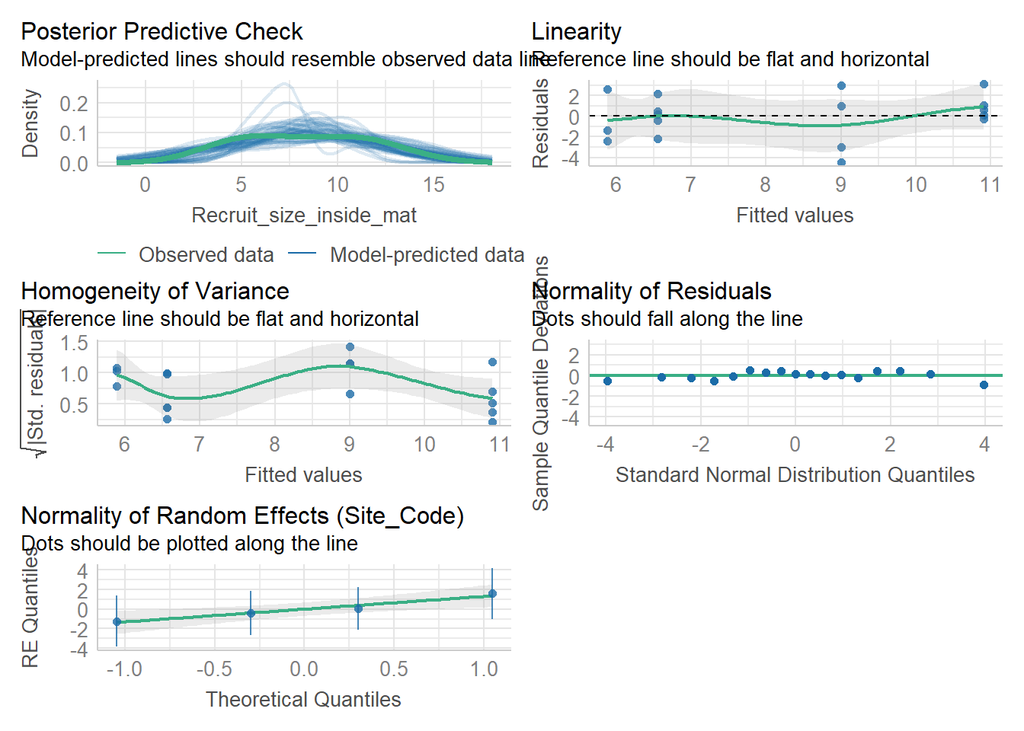

Plot relationship

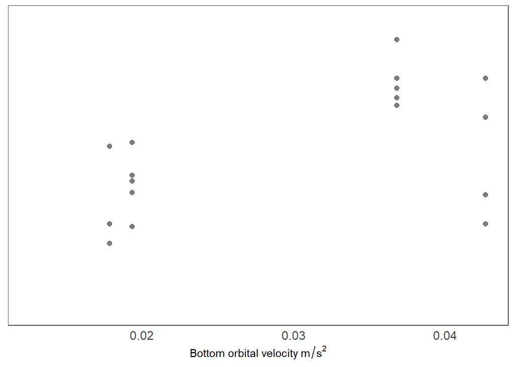

```r
SD_Recl9 <- ggplot() +
   geom_point(data = Rec_l9,                      # adding the raw data (scaled values)
              aes(x = Mean_SD, y = Recruit_size_inside_mat), size= 2, alpha=.5) +
   labs(x = expression ("Bottom orbital velocity"~m/s^2), y = "log(Total recruitment)") +
   Theme1 +
  scale_y_continuous(limits = c(0, 15), breaks = seq(0,15, by = 3))+
    theme(axis.title.y=element_blank(),
        axis.text.y=element_blank(), axis.title.x=element_text(size = 11))

SD_Recl9
```

10. Light intensity

```r
my_lmerOX <- glmmTMB(Recruit_size_inside_mat ~ Mean_Intensity + (1|Site_Code), data=Rec_l9, family =gaussian())
summary(my_lmerOX)
```

```
##  Family: gaussian  ( identity )
## Formula:          Recruit_size_inside_mat ~ Mean_Intensity + (1 | Site_Code)
## Data: Rec_l9
##
##      AIC      BIC   logLik deviance df.resid
##     89.8     93.2    -40.9     81.8       13
##
## Random effects:
##
## Conditional model:
##  Groups    Name        Variance Std.Dev.
##  Site_Code (Intercept) 3.801    1.950
##  Residual              5.185    2.277
## Number of obs: 17, groups:  Site_Code, 4
##
## Dispersion estimate for gaussian family (sigma^2): 5.19
##
## Conditional model:
##                 Estimate Std. Error z value Pr(>|z|)
## (Intercept)    2.6593627  7.6957981   0.346    0.730
## Mean_Intensity 0.0005343  0.0007502   0.712    0.476
```

```r
r.squaredGLMM(my_lmerOX)
```

```
##             R2m       R2c
## [1,] 0.07486317 0.4661737
```

```r
AICc(my_lmerOX)
```

```
## [1] 93.16838
```

```r
check_model(my_lmerOX)
```

```
## `check_outliers()` does not yet support models of class `glmmTMB`.
```

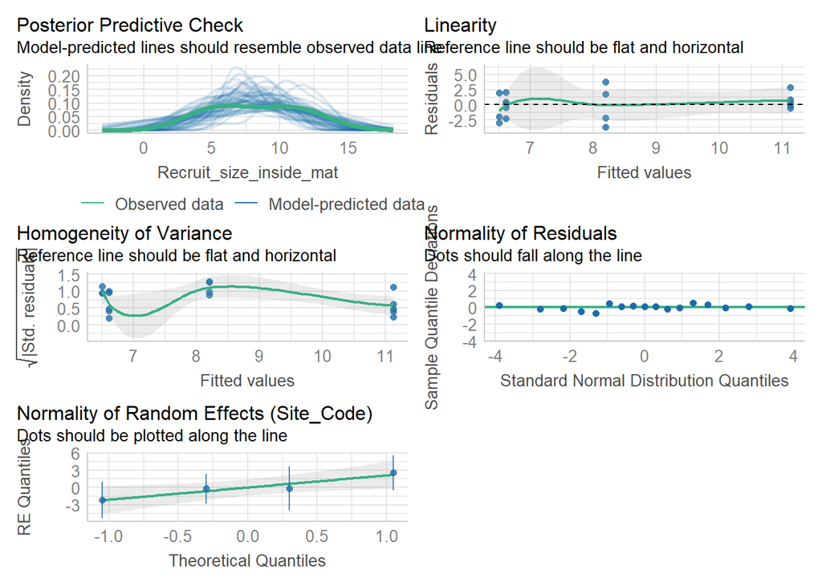

Plot relationship

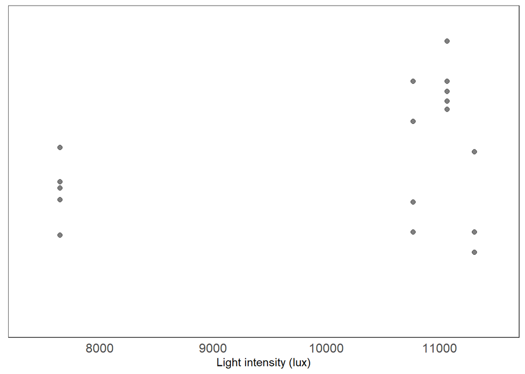

```r
T_Recl9 <- ggplot() +
   geom_point(data = Rec_l9,                      # adding the raw data (scaled values)
              aes(x = Mean_Intensity, y = Recruit_size_inside_mat), size= 2, alpha=.5) +
   labs(x = "Light intensity (lux)", y = "log(Recruit length + 1)") +
   Theme1 +
  scale_y_continuous(limits = c(0, 15), breaks = seq(0,15, by = 3))+
  scale_x_continuous(limits = c(7400, 11500), breaks = seq(8000,11000, by = 1000))+
  theme(axis.title.y=element_blank(),
        axis.text.y=element_blank(), axis.title.x=element_text(size = 11))

T_Recl9
```

11. Create Supplementary Figure 4

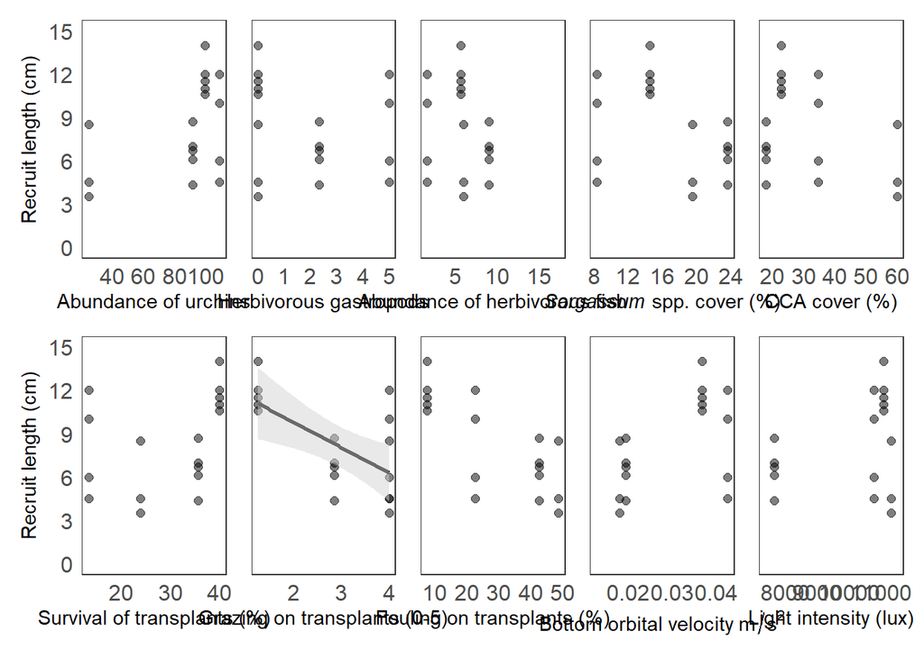

```r
U_Recl9 + SN_Recl9 + HFplot + SAR_Recl9 + EC_Recl9+ Surv_Recl9 + Gr_Recl9+ Fo_Recl9 + SD_Recl9 + T_Recl9 + plot_layout(ncol=5)
```

```r
ggsave("Rl9_predictors.jpeg", width = 30, height = 15, units = "cm")
```

# **3)** Long-term tree island expansion and scalability

## **Part 1:** Importing data

```r
Transplants <- read.csv("Data&AnalysesPhyll/Transplants.csv")
Expansion_surveys <- read.csv("Data&AnalysesPhyll/Expansion_surveys_data_occurrence.csv", fileEncoding="latin1") #1 adult deleted in LB due to missing data
Cover <- read.csv("Data&AnalysesPhyll/BenthicCover_Restanalysis.csv")
```

## **Part 2:** Data structure, manipulation and calculations

### **2a)** Transplants

1. Check data structure

```r
str(Transplants)
```

```
## 'data.frame':    14 obs. of  9 variables:
##  $ Site                : chr  "Whale Beach" "Newport" "Freshwater " "Manly" ...
##  $ Year                : int  2017 2020 2017 2019 2017 2017 2016 2017 2017 2012 ...
##  $ Season              : chr  "Spring" "Spring" "Spring" "Autumn" ...
##  $ Transplanting.events: int  1 3 6 10 1 4 1 5 2 1 ...
##  $ Transplanted        : int  180 150 670 895 210 380 300 750 360 600 ...
##  $ Restored            : int  0 0 233 218 0 287 0 92 0 673 ...
##  $ Area                : num  0 0 1055 3542 0 ...
##  $ Extension           : int  0 0 103 159 0 232 0 235 0 360 ...
##  $ Transplanting_winter: int  1 1 5 5 1 4 1 5 2 1 ...
```

### **2b)** Expansion surveys - co-occurrence data

1. Check data structure

```r
str(Expansion_surveys)
```

```
## 'data.frame':    259 obs. of  12 variables:
##  $ Site_Code            : chr  "CO" "CO" "CO" "CO" ...
##  $ Site                 : chr  "Coogee" "Coogee" "Coogee" "Coogee" ...
##  $ Longitude            : chr  "151.2591473" "151.2593216" "151.2598582" "151.259939" ...
##  $ Latitude             : chr  "-33.92380572" "-33.92409691" "-33.92494189" "-33.92501431" ...
##  $ Date                 : chr  "7/11/2023" "7/11/2023" "7/11/2023" "7/11/2023" ...
##  $ Scorer_1             : chr  "Cata" "Cata" "Cata" "Cata" ...
##  $ Buoy                 : chr  "Rachel" "Rachel" "Rachel" "Rachel" ...
##  $ Time                 : chr  "8:52:00 AM" "9:00:00 AM" "9:11:00 AM" "9:14:00 AM" ...
##  $ Abundance            : int  1 1 1 1 1 1 1 1 1 1 ...
##  $ Life_stage           : chr  "Adult" "Adult" "Adult" "Adult" ...
##  $ Associated_community1: chr  "Ecklonia" "Ecklonia" "Ecklonia" "Ecklonia" ...
##  $ Associated_community2: chr  "Sargassum" "Sargassum" "Sargassum" "Sargassum" ...
```

2. Calculate total abundance per site

```r
Expansion_abundances <- Expansion_surveys %>%
  group_by(Site, Site_Code)%>%
  summarise(Total_abundance = sum(Abundance))
Expansion_abundances
```

```
## # A tibble: 13 × 3
## # Groups:   Site [13]
##    Site             Site_Code Total_abundance
##    <chr>            <chr>               <int>
##  1 "Cape Banks "    CB                      0
##  2 "Coogee"         CO                     92
##  3 "Freshwater"     FW                    233
##  4 "Kurnell "       KU                      0
##  5 "Little Bay"     LI                     44
##  6 "Long Bay North" LN                    672
##  7 "Long Bay South" LS                      0
##  8 "Manly"          MAN                   218
##  9 "Maroubra "      MAR                     0
## 10 "Newport"        NE                      0
## 11 "North Bondi "   NB                    287
## 12 "South Head"     SO                      0
## 13 "Whale Beach"    WB                      0
```

3. Calculate percent of associated communityper crayweed occurrence

```r
Community1_percent <- Expansion_surveys %>%
  group_by(Site, Site_Code, Associated_community1)%>%
  summarise(Crayweed_number = sum(Abundance, na.rm=TRUE)) %>%
  mutate(percent =  100 *Crayweed_number/sum(Crayweed_number))
Community1_percent
```

```
## # A tibble: 25 × 5
## # Groups:   Site, Site_Code [13]
##    Site          Site_Code Associated_community1 Crayweed_number percent
##    <chr>         <chr>     <chr>                           <int>   <dbl>
##  1 "Cape Banks " CB        None                                0  NaN
##  2 "Coogee"      CO        Ecklonia                           69   75
##  3 "Coogee"      CO        Sargassum                          22   23.9
##  4 "Coogee"      CO        TURF                                1    1.09
##  5 "Freshwater"  FW        Bare_rock                          14    6.01
##  6 "Freshwater"  FW        Ecklonia                          112   48.1
##  7 "Freshwater"  FW        Sargassum                         107   45.9
##  8 "Kurnell "    KU        None                                0  NaN
##  9 "Little Bay"  LI        Ecklonia                           32   72.7
## 10 "Little Bay"  LI        Sargassum                          12   27.3
## # ℹ 15 more rows
```

4. Fill empty columns with 0 (for sites in which some types were not observed)

```r
Community_wide <- Community1_percent%>%
ungroup() %>%
dplyr::select(-Crayweed_number) %>%
pivot_wider(names_from = Associated_community1, values_from = percent, values_fill = 0)

Community_long <- Community_wide %>%
  gather(Associated_community1, percent, None:CA)
```

5. Filter data and calculate mean, sd and se

```r
Restored <- filter(Community_long, Site_Code == "CO"| Site_Code == "FW"| Site_Code == "NB" | Site_Code == "MAN"| Site_Code == "LN"| Site_Code == "LI") #only successfully restored sites


Community_mean_Site <- Community_long%>%
  group_by(Associated_community1)%>%
  summarise(Crayweed_number = mean(percent, na.rm=TRUE))


Community_mean <- Restored%>%
  group_by(Associated_community1)%>%
  summarise(Percent_mean = mean(percent), n = n(), sd = sd(percent), se = sd/sqrt(n))

Community_mean1 <- Community_mean %>%
  filter(Associated_community1 != "None")
```

### **2c)** Cover

1. Check data structure

```r
str(Cover)
```

```
## 'data.frame':    202 obs. of  17 variables:
##  $ Time                 : chr  "AFTER" "AFTER" "AFTER" "AFTER" ...
##  $ Status               : chr  "TRANSPLANT" "TRANSPLANT" "TRANSPLANT" "TRANSPLANT" ...
##  $ Site_Code            : chr  "CO" "CO" "CO" "CO" ...
##  $ Survey_Period        : int  3 3 3 3 3 3 3 3 3 3 ...
##  $ Transect             : int  1 1 1 1 1 2 2 2 2 2 ...
##  $ Photo                : chr  "CO_S2_T1PC220075.JPG" "CO_S2_T1PC220076.JPG" "CO_S2_T1PC220084.JPG" "CO_S2_T1PC220090.JPG" ...
##  $ Animal               : int  0 0 10 0 0 0 0 0 5 0 ...
##  $ CA                   : int  0 10 0 0 0 0 0 0 5 5 ...
##  $ Crayweed             : int  0 0 0 0 0 0 0 0 0 0 ...
##  $ Encrusting_macroalgae: int  90 25 15 5 90 5 15 0 5 0 ...
##  $ Ecklonia             : int  0 10 0 0 0 0 0 35 0 0 ...
##  $ Sargassum            : int  5 55 0 25 0 0 0 40 10 10 ...
##  $ Caulerpa             : int  0 0 0 0 0 0 0 0 0 0 ...
##  $ Understory           : int  5 0 70 55 5 45 70 5 10 60 ...
##  $ Substrate            : int  0 0 5 15 5 50 15 20 65 25 ...
##  $ Unknown              : int  0 0 0 0 0 0 0 0 0 0 ...
##  $ Total                : int  100 100 100 100 100 100 100 100 100 100 ...
```

2. Filter data

```r
Cover$Survey_Period <- as.factor(Cover$Survey_Period)

Benthic <- Cover  %>%
replace(is.na(.),0)  %>%
  dplyr::select(-Total) %>%
 filter(Site_Code == "CO"| Site_Code == "FW"| Site_Code == "NB")
```

3. Transform Benthic to long format

```r
Benthic_long <- Benthic %>%
  gather(Cover_type, Cover_percentage, Animal:Unknown)
```

4. Calculate mean, sd, and se by cover type

```r
Benthic_mean <- Benthic_long %>%
  group_by(Site_Code, Survey_Period, Time, Cover_type)%>%
  summarise(Mean_cover = mean(Cover_percentage),n = n(), sd = sd(Cover_percentage), se = sd/sqrt(n))
```

5. Calculate means by site for all times

```r
Benthic_sitemerged <- Benthic_long %>%
  group_by (Site_Code, Cover_type) %>%
  summarise(Mean_Cover = mean(Cover_percentage),n = n(), sd = sd(Cover_percentage), se = sd/sqrt(n))
```

## **Part 3:** Analyse relationships among transplants and restored crayweed

In this part we aimed to explore the effect of the active transplanting on restoration outcomes

### **3a)** Effect of transplanting events on crayweed expansion

1. Correlate possible explanatory variables

```r
cor.test(Transplants$Transplanted, Transplants$Transplanting.events, method=c("pearson"))
```

```
##
##  Pearson's product-moment correlation
##
## data:  Transplants$Transplanted and Transplants$Transplanting.events
## t = 1.9664, df = 12, p-value = 0.07281
## alternative hypothesis: true correlation is not equal to 0
## 95 percent confidence interval:
##  -0.05001876  0.81164882
## sample estimates:
##      cor
## 0.493662
```

```r
cor.test(Transplants$Transplanting_winter, Transplants$Transplanting.events, method=c("pearson"))
```

```
##
##  Pearson's product-moment correlation
##
## data:  Transplants$Transplanting_winter and Transplants$Transplanting.events
## t = 6.1908, df = 12, p-value = 4.651e-05
## alternative hypothesis: true correlation is not equal to 0
## 95 percent confidence interval:
##  0.6370652 0.9591453
## sample estimates:
##       cor
## 0.8726702
```

2. Transplanting events on area

```r
Transplants$Area <- as.numeric(Transplants$Area )
model<- lm(sqrt(Area) ~ Transplanting.events, data = Transplants)
summary(model)
```

```
##
## Call:
## lm(formula = sqrt(Area) ~ Transplanting.events, data = Transplants)
##
## Residuals:
##     Min      1Q  Median      3Q     Max
## -24.316 -11.486 -11.136   8.361  57.174
##
## Coefficients:
##                      Estimate Std. Error t value Pr(>|t|)
## (Intercept)             4.546     10.142   0.448   0.6620
## Transplanting.events    6.590      2.677   2.462   0.0299 *
## ---
## Signif. codes:  0 '***' 0.001 '**' 0.01 '*' 0.05 '.' 0.1 ' ' 1
##
## Residual standard error: 25.72 on 12 degrees of freedom
## Multiple R-squared:  0.3356, Adjusted R-squared:  0.2803
## F-statistic: 6.062 on 1 and 12 DF,  p-value: 0.02992
```

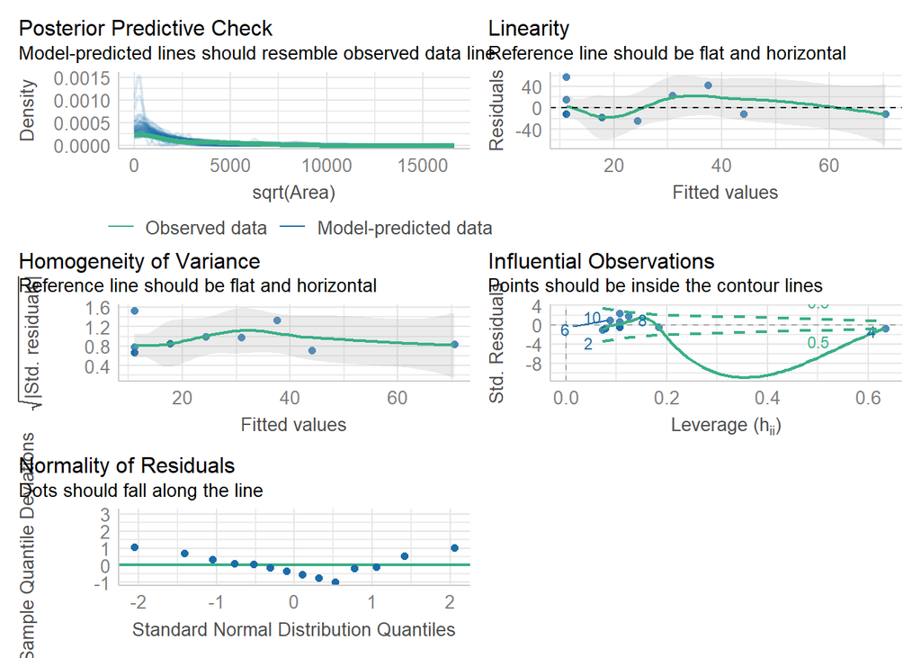

```r
check_model(model)
```

3. Transplanting events on patch extension

```r
model<- lm(sqrt(Extension) ~ Transplanting.events, data = Transplants)
summary(model)
```

```
##
## Call:
## lm(formula = sqrt(Extension) ~ Transplanting.events, data = Transplants)
##
## Residuals:
##    Min     1Q Median     3Q    Max
## -5.925 -3.190 -3.094  2.477 15.880
##
## Coefficients:
##                      Estimate Std. Error t value Pr(>|t|)
## (Intercept)            1.6785     2.5517   0.658   0.5231
## Transplanting.events   1.4153     0.6734   2.102   0.0574 .
## ---
## Signif. codes:  0 '***' 0.001 '**' 0.01 '*' 0.05 '.' 0.1 ' ' 1
##
## Residual standard error: 6.472 on 12 degrees of freedom
## Multiple R-squared:  0.269,  Adjusted R-squared:  0.2081
## F-statistic: 4.417 on 1 and 12 DF,  p-value: 0.05738
```

```r
Anova(model)
```

```
## Anova Table (Type II tests)
##
## Response: sqrt(Extension)
##                      Sum Sq Df F value  Pr(>F)
## Transplanting.events 185.00  1  4.4168 0.05738 .
## Residuals            502.63 12
## ---
## Signif. codes:  0 '***' 0.001 '**' 0.01 '*' 0.05 '.' 0.1 ' ' 1
```

```r
r2(model)
```

```
## # R2 for Linear Regression
##        R2: 0.269
##   adj. R2: 0.208
```

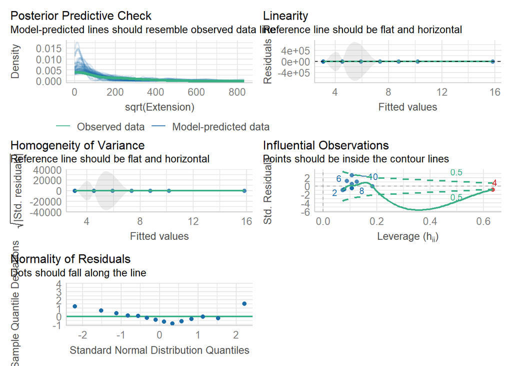

```r
check_model(model)
```

4. Plot relationship

Transplanting events vs area

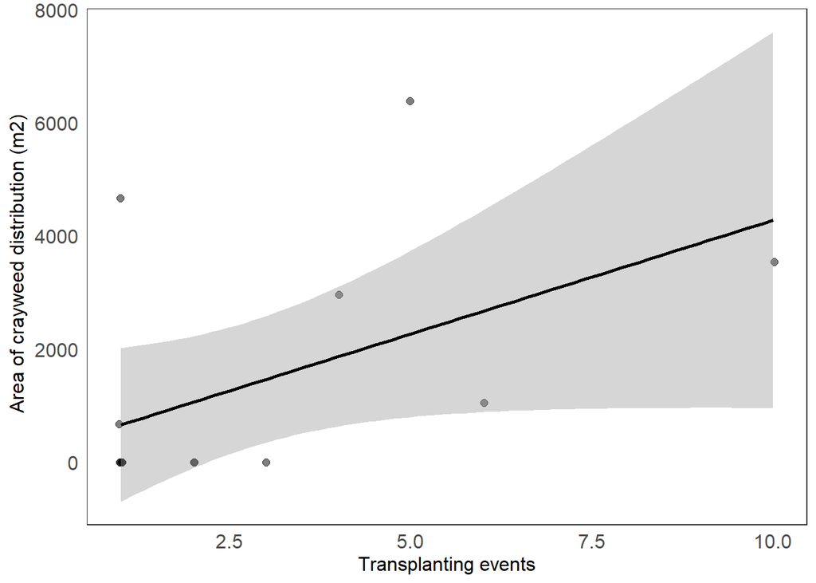

```r
ggplot(Transplants, aes(Transplanting.events, Area)) +
geom_jitter( size= 2, width = 0.02, height= 0.3, alpha=.5 )+
  geom_smooth(method = lm, col= "Black") +
Theme1  +
labs( y=expression ("Area of crayweed distribution (m2)"), x="Transplanting events")
```

```r
ggsave("Area.jpeg", width = 11, height = 8.5, units = "cm")
```

Transplanting events vs extension

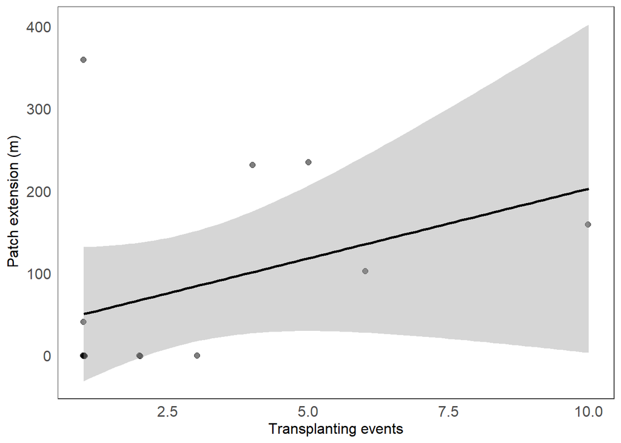

```r
ggplot(Transplants, aes(Transplanting.events, Extension)) +
geom_jitter( size= 2, width = 0.02, height= 0.3, alpha=.5 )+
  geom_smooth(method = lm, col= "Black") +
Theme1  +
labs( y=expression ("Patch extension (m)"), x="Transplanting events")
```

### **3b)** Effects of transplanting events in winter on crayweed expansion

1. Transplanting events on area

```r
Transplants$Area <- as.numeric(Transplants$Area)
model<- lm(sqrt(Area) ~ Transplanting_winter, data = Transplants)
summary(model)
```

```
##
## Call:
## lm(formula = sqrt(Area) ~ Transplanting_winter, data = Transplants)
##
## Residuals:
##     Min      1Q  Median      3Q     Max
## -23.510 -10.798  -5.148   8.195  57.512
##
## Coefficients:
##                      Estimate Std. Error t value Pr(>|t|)
## (Intercept)           -0.5014     9.2984  -0.054  0.95788
## Transplanting_winter  11.2992     3.3953   3.328  0.00602 **
## ---
## Signif. codes:  0 '***' 0.001 '**' 0.01 '*' 0.05 '.' 0.1 ' ' 1
##
## Residual standard error: 22.76 on 12 degrees of freedom
## Multiple R-squared:   0.48,  Adjusted R-squared:  0.4366
## F-statistic: 11.07 on 1 and 12 DF,  p-value: 0.006021
```

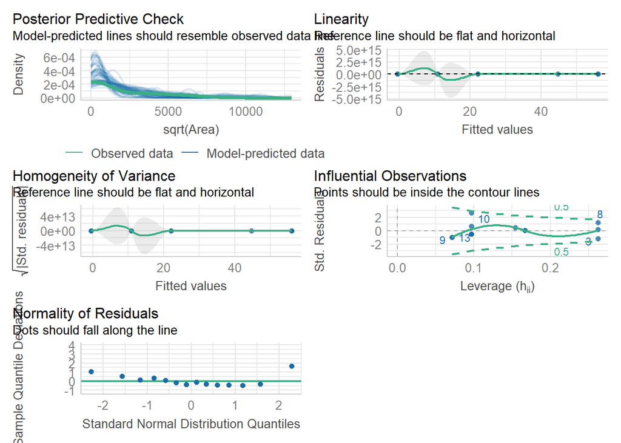

```r
check_model(model)
```

3. Transplanting events on patch extension

```r
model<- lm(sqrt(Extension) ~ Transplanting_winter, data = Transplants)
summary(model)
```

```
##
## Call:
## lm(formula = sqrt(Extension) ~ Transplanting_winter, data = Transplants)
##
## Residuals:
##    Min     1Q Median     3Q    Max
## -5.440 -2.909 -1.655  1.627 16.065
##
## Coefficients:
##                      Estimate Std. Error t value Pr(>|t|)
## (Intercept)            0.3777     2.3581    0.16   0.8754
## Transplanting_winter   2.5313     0.8611    2.94   0.0124 *
## ---
## Signif. codes:  0 '***' 0.001 '**' 0.01 '*' 0.05 '.' 0.1 ' ' 1
##
## Residual standard error: 5.772 on 12 degrees of freedom
## Multiple R-squared:  0.4187, Adjusted R-squared:  0.3702
## F-statistic: 8.642 on 1 and 12 DF,  p-value: 0.01238
```

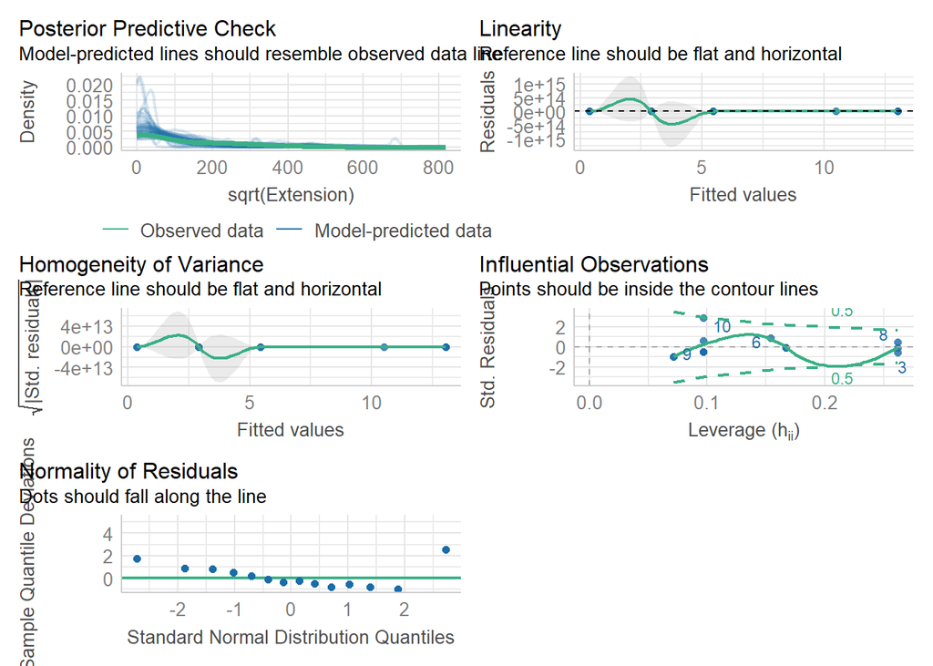

```r
check_model(model)
```

4. Plot relationship

Transplanting events vs area

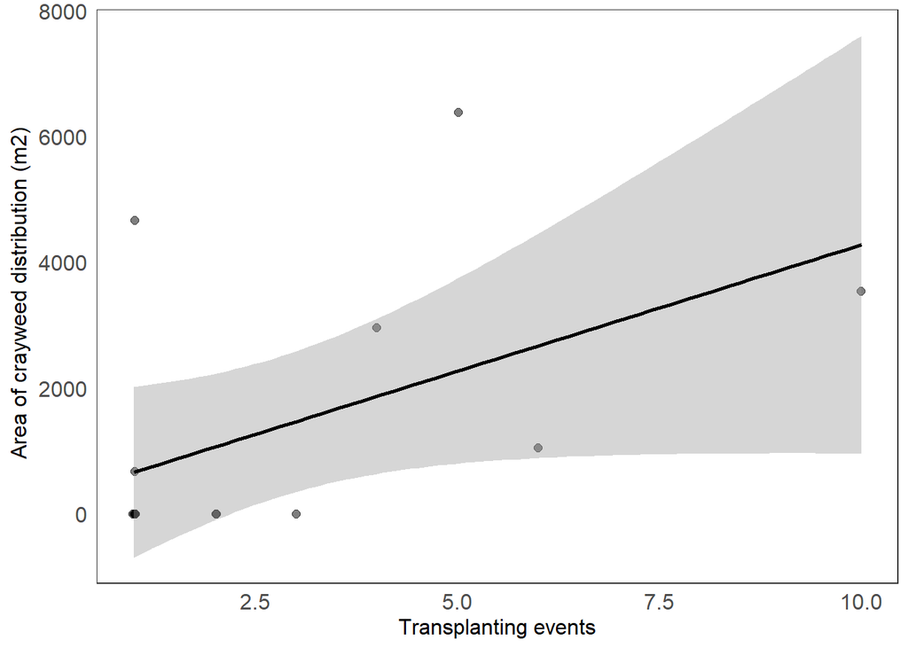

```r
ggplot(Transplants, aes(Transplanting.events, Area)) +
geom_jitter( size= 2, width = 0.02, height= 0.3, alpha=.5 )+
  geom_smooth(method = lm, col= "Black") +
Theme1  +
labs( y=expression ("Area of crayweed distribution (m2)"), x="Transplanting events")
```

```r
ggsave("Area.jpeg", width = 11, height = 8.5, units = "cm")
```

Transplanting events vs extension

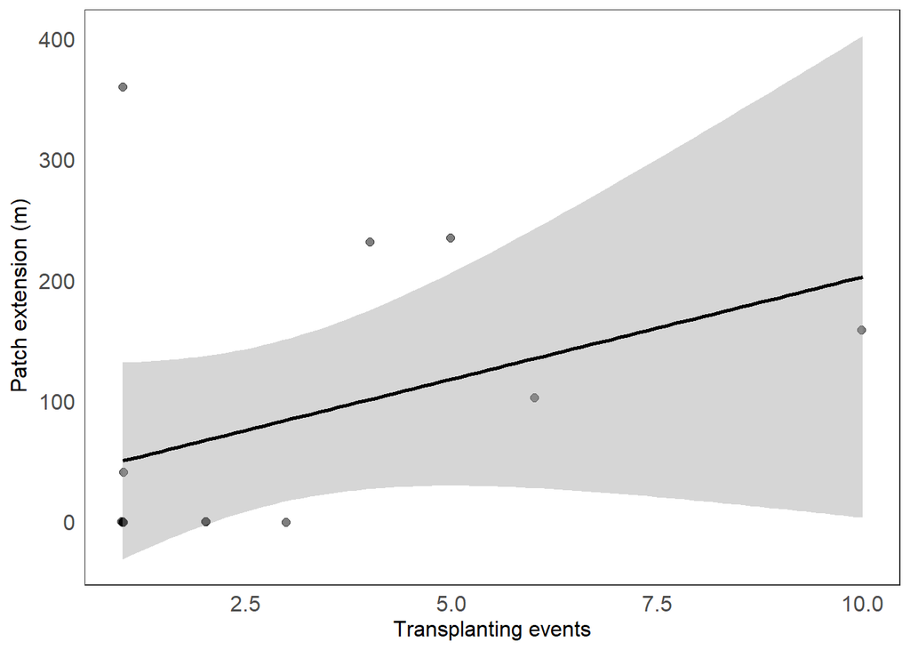

```r
ggplot(Transplants, aes(Transplanting.events, Extension)) +
geom_jitter( size= 2, width = 0.02, height= 0.3, alpha=.5 )+
  geom_smooth(method = lm, col= "Black") +
Theme1  +
labs( y=expression ("Patch extension (m)"), x="Transplanting events")
```

_______________________________________________________________________________

## **Part 4:** Examine patterns in associated community

1. Frequency of crayweed occurrence per associated community in each site

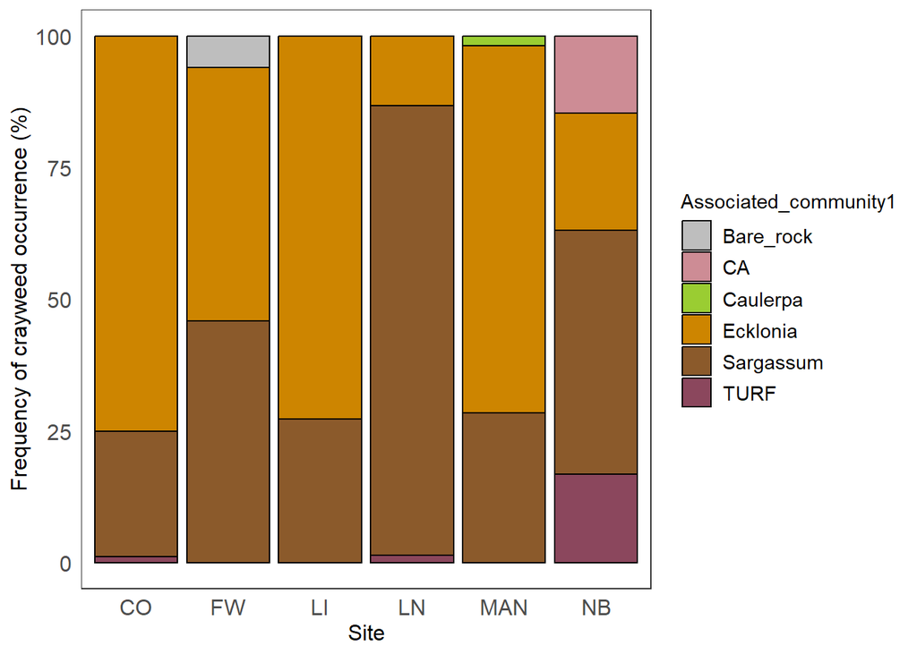

```r
Community1_percent %>%
  filter(Crayweed_number > 0) %>%
ggplot() +
  geom_bar(aes(x= Site_Code, y= percent, fill = Associated_community1), stat="identity", color = "black") +
  Theme1 +
labs(y="Frequency of crayweed occurrence (%)", x="Site") +
  scale_fill_manual(values=c("grey", "lightpink3", "olivedrab3", "orange3", "tan4", "palevioletred4")) +
theme(legend.title=element_text(size=11),
    legend.text=element_text(size=11))
```

```r
ggsave("Community_site.jpeg", width = 16, height = 9, units = "cm")
```

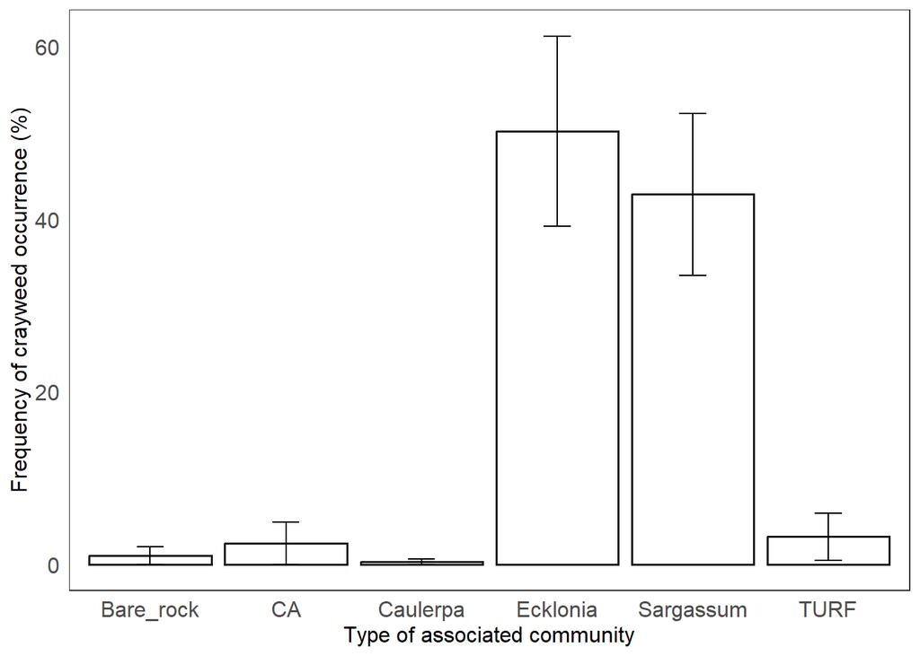

```r
Community_mean1  %>%
ggplot() +
geom_bar(aes(x = Associated_community1, y = Percent_mean), stat="identity", color="grey10", size=0.7, position=position_dodge(), fill= "white") +
 geom_errorbar(aes(x = Associated_community1, ymin=Percent_mean-se, ymax=Percent_mean+se), width=.2, position=position_dodge(0.9)) +
  Theme1 +
labs(y="Frequency of crayweed occurrence (%)", x="Type of associated community") +
theme(axis.title.x=element_text(size = 12))
```

```r
ggsave("Community_mean.jpeg", width = 15, height = 9.5, units = "cm")
```

```r
my_lm <- glmmTMB(percent ~ Associated_community1  + (1|Site), data=Restored, tweedie())
summary(my_lm)
```

```
##  Family: tweedie  ( log )
## Formula:          percent ~ Associated_community1 + (1 | Site)
## Data: Restored
##
##      AIC      BIC   logLik deviance df.resid
##       NA       NA       NA       NA       32
##
## Random effects:
##
## Conditional model:
##  Groups Name        Variance  Std.Dev.
##  Site   (Intercept) 5.189e-15 7.203e-08
## Number of obs: 42, groups:  Site, 6
##
## Dispersion parameter for tweedie family (): 5.34
##
## Conditional model:
##                                  Estimate Std. Error z value Pr(>|z|)
## (Intercept)                     1.426e-03  9.426e-01   0.002  0.99879
## Associated_community1CA         8.902e-01  1.170e+00   0.761  0.44666
## Associated_community1Caulerpa  -1.186e+00  1.705e+00  -0.696  0.48662
## Associated_community1Ecklonia   3.914e+00  9.735e-01   4.021  5.8e-05 ***
## Associated_community1None      -2.743e+01  1.500e+04  -0.002  0.99854
## Associated_community1Sargassum  3.757e+00  9.770e-01   3.846  0.00012 ***
## Associated_community1TURF       1.159e+00  1.134e+00   1.022  0.30685
## ---
## Signif. codes:  0 '***' 0.001 '**' 0.01 '*' 0.05 '.' 0.1 ' ' 1
```

```r
r.squaredGLMM(my_lm)
```

```
##      R2m R2c
## [1,]   1   1
```

```r
Anova(my_lm)
```

```
## Analysis of Deviance Table (Type II Wald chisquare tests)
##
## Response: percent
##                        Chisq Df Pr(>Chisq)
## Associated_community1 55.344  6   3.95e-10 ***
## ---
## Signif. codes:  0 '***' 0.001 '**' 0.01 '*' 0.05 '.' 0.1 ' ' 1
```

```r
check_model(my_lm)
```

```
## `check_outliers()` does not yet support models of class `glmmTMB`.
```

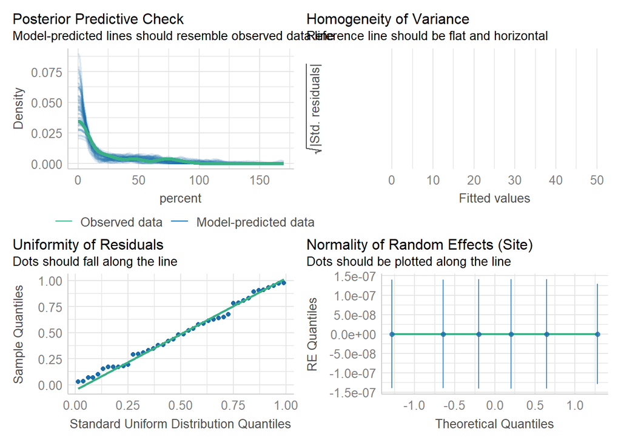

```r
emm3 = emmeans(my_lm, specs = pairwise ~ Associated_community1, type = "response", adjust = "none")
emm3
```

```
## $emmeans
##  Associated_community1 response     SE  df asymp.LCL asymp.UCL
##  Bare_rock                1.001  0.944 Inf    0.1579         6
##  CA                       2.439  1.690 Inf    0.6274         9
##  Caulerpa                 0.306  0.435 Inf    0.0189         5
##  Ecklonia                50.177 12.210 Inf   31.1449        81
##  None                     0.000  0.000 Inf    0.0000       Inf
##  Sargassum               42.885 11.018 Inf   25.9187        71
##  TURF                     3.192  2.015 Inf    0.9264        11
##
## Confidence level used: 0.95
## Intervals are back-transformed from the log scale
##
## $contrasts
##  contrast                 ratio       SE  df null z.ratio p.value
##  Bare_rock / CA        0.00e+00 0.00e+00 Inf    1  -0.761  0.4467
##  Bare_rock / Caulerpa  3.00e+00 6.00e+00 Inf    1   0.696  0.4866
##  Bare_rock / Ecklonia  0.00e+00 0.00e+00 Inf    1  -4.021  0.0001
##  Bare_rock / None      8.20e+11 1.23e+16 Inf    1   0.002  0.9985
##  Bare_rock / Sargassum 0.00e+00 0.00e+00 Inf    1  -3.846  0.0001
##  Bare_rock / TURF      0.00e+00 0.00e+00 Inf    1  -1.022  0.3069
##  CA / Caulerpa         8.00e+00 1.30e+01 Inf    1   1.314  0.1890
##  CA / Ecklonia         0.00e+00 0.00e+00 Inf    1  -4.119  <.0001
##  CA / None             2.00e+12 3.00e+16 Inf    1   0.002  0.9985
##  CA / Sargassum        0.00e+00 0.00e+00 Inf    1  -3.880  0.0001
##  CA / TURF             1.00e+00 1.00e+00 Inf    1  -0.287  0.7741
##  Caulerpa / Ecklonia   0.00e+00 0.00e+00 Inf    1  -3.538  0.0004
##  Caulerpa / None       2.50e+11 3.76e+15 Inf    1   0.002  0.9986
##  Caulerpa / Sargassum  0.00e+00 0.00e+00 Inf    1  -3.424  0.0006
##  Caulerpa / TURF       0.00e+00 0.00e+00 Inf    1  -1.509  0.1314
##  Ecklonia / None       4.11e+13 6.16e+17 Inf    1   0.002  0.9983
##  Ecklonia / Sargassum  1.00e+00 0.00e+00 Inf    1   0.444  0.6572
##  Ecklonia / TURF       1.60e+01 1.10e+01 Inf    1   4.073  <.0001
##  None / Sargassum      0.00e+00 0.00e+00 Inf    1  -0.002  0.9983
##  None / TURF           0.00e+00 0.00e+00 Inf    1  -0.002  0.9985
##  Sargassum / TURF      1.30e+01 9.00e+00 Inf    1   3.812  0.0001
##
## Tests are performed on the log scale
```

# **4)** R Session Information

In this part, information about the operating system and R packages attached during the production of this document can be found

```r
sessionInfo() %>% pander
```

**R version 4.4.1 (2024-06-14 ucrt)**

**Platform:** x86_64-w64-mingw32/x64

**locale:** *LC_COLLATE=English_Australia.utf8*, *LC_CTYPE=English_Australia.utf8*, *LC_MONETARY=English_Australia.utf8*, *LC_NUMERIC=C* and *LC_TIME=English_Australia.utf8*

**attached base packages:** *stats*, *graphics*, *grDevices*, *utils*, *datasets*, *methods* and *base*

**other attached packages:** *fitdistrplus(v.1.2-2)*, *survival(v.3.6-4)*, *MASS(v.7.3-60.2)*, *lmerTest(v.3.1-3)*, *performance(v.0.13.0)*, *glmmTMB(v.1.1.10)*, *gamm4(v.0.2-6)*, *mgcv(v.1.9-3)*, *nlme(v.3.1-167)*, *car(v.3.1-2)*, *carData(v.3.0-5)*, *GAD(v.2.0)*, *ggeffects(v.1.7.0)*, *MuMIn(v.1.48.4)*, *outliers(v.0.15)*, *corrplot(v.0.95)*, *wesanderson(v.0.3.7)*, *emmeans(v.1.10.2)*, *lme4(v.1.1-35.4)*, *Matrix(v.1.7-0)*, *pander(v.0.6.5)*, *patchwork(v.1.3.0)*, *vegan(v.2.6-6.1)*, *lattice(v.0.22-6)*, *permute(v.0.9-7)*, *readr(v.2.1.5)*, *dplyr(v.1.1.4)*, *tidyr(v.1.3.1)*, *ggplot2(v.3.5.1)* and *summarytools(v.1.0.1)*

**loaded via a namespace (and not attached):** *Rdpack(v.2.6)*, *tcltk(v.4.4.1)*, *sandwich(v.3.1-1)*, *rlang(v.1.1.4)*, *magrittr(v.2.0.3)*, *multcomp(v.1.4-26)*, *matrixStats(v.1.5.0)*, *compiler(v.4.4.1)*, *systemfonts(v.1.2.1)*, *vctrs(v.0.6.5)*, *reshape2(v.1.4.4)*, *stringr(v.1.5.1)*, *pkgconfig(v.2.0.3)*, *crayon(v.1.5.3)*, *fastmap(v.1.2.0)*, *backports(v.1.5.0)*, *magick(v.2.8.3)*, *labeling(v.0.4.3)*, *utf8(v.1.2.4)*, *rmarkdown(v.2.29)*, *tzdb(v.0.4.0)*, *nloptr(v.2.1.0)*, *ragg(v.1.3.2)*, *bit(v.4.0.5)*, *purrr(v.1.0.2)*, *xfun(v.0.51)*, *cachem(v.1.1.0)*, *jsonlite(v.1.9.1)*, *pryr(v.0.1.6)*, *parallel(v.4.4.1)*, *cluster(v.2.1.6)*, *R6(v.2.6.1)*, *bslib(v.0.9.0)*, *stringi(v.1.8.4)*, *boot(v.1.3-30)*, *lubridate(v.1.9.3)*, *jquerylib(v.0.1.4)*, *numDeriv(v.2016.8-1.1)*, *estimability(v.1.5.1)*, *Rcpp(v.1.0.12)*, *knitr(v.1.50)*, *DHARMa(v.0.4.6)*, *zoo(v.1.8-12)*, *base64enc(v.0.1-3)*, *splines(v.4.4.1)*, *timechange(v.0.3.0)*, *tidyselect(v.1.2.1)*, *rstudioapi(v.0.16.0)*, *abind(v.1.4-5)*, *yaml(v.2.3.8)*, *TMB(v.1.9.16)*, *codetools(v.0.2-20)*, *tibble(v.3.2.1)*, *plyr(v.1.8.9)*, *bayestestR(v.0.15.1)*, *withr(v.3.0.2)*, *coda(v.0.19-4.1)*, *evaluate(v.1.0.3)*, *pillar(v.1.10.1)*, *checkmate(v.2.3.1)*, *stats4(v.4.4.1)*, *reformulas(v.0.4.0)*, *insight(v.1.1.0)*, *generics(v.0.1.3)*, *vroom(v.1.6.5)*, *hms(v.1.1.3)*, *munsell(v.0.5.1)*, *scales(v.1.3.0)*, *minqa(v.1.2.7)*, *xtable(v.1.8-4)*, *glue(v.1.7.0)*, *tools(v.4.4.1)*, *see(v.0.10.0)*, *mvtnorm(v.1.2-5)*, *rapportools(v.1.1)*, *grid(v.4.4.1)*, *rbibutils(v.2.2.16)*, *datawizard(v.1.0.2)*, *colorspace(v.2.1-0)*, *cli(v.3.6.2)*, *textshaping(v.0.4.0)*, *gtable(v.0.3.6)*, *sass(v.0.4.9)*, *digest(v.0.6.35)*, *ggrepel(v.0.9.6)*, *TH.data(v.1.1-2)*, *farver(v.2.1.2)*, *htmltools(v.0.5.8.1)*, *lifecycle(v.1.0.4)* and *bit64(v.4.0.5)*